# Analysis of Colorado Springs Data- 1988-1990

Vivek Anand

April 2, 2019

```r
# Reads Data into a graph to be handled
library(igraph)
nodes<-read.table("nodes.tsv",sep='\t',header=TRUE)
nodes$sex.worker[is.na(nodes$sex.worker)]<-0
sum(nodes$sex.worker)
```

```
## [1] 288
```

```r
nodes$sex.work.client[is.na(nodes$sex.work.client)]<-1
sum(nodes$sex.work.client)
```

```
## [1] 493
```

```r
edges<-read.table("edges.tsv",sep='\t',header=TRUE)
head(nodes)
```

```
##   id race gender sex.worker pimp sex.work.client drug.dealer drug.cook
## 1  1    4      1          1    0               0           0         0
## 2  2    4      1          1    0               0           0         0
## 3  3    4      0          0    0               1           0         0
## 4  4    5      1          0    0               0           0         0
## 5  5    4      0          0    0               1           1         1
## 6  6    2      0          0    0               1           0         0
##   thief retired housewife disabled unemployed homeless
## 1     0       0         0        0          1        0
## 2     0       0         1        0          1        0
## 3     0       1         0        0          0        0
## 4     0       0         0        0          0        0
## 5     0       0         0        0          0        0
## 6     0       0         0        0          0        0
```

```r
head(edges)
```

```
##   node1 node2
## 1     1    10
## 2     1    16
## 3     1    17
## 4     1    25
## 5     1    52
## 6     1    62
```

```r
g1=graph_from_data_frame(d=edges, vertices=nodes, directed=FALSE)
#Simplify graph to remove multiple edges and loops
g1<-simplify(g1,remove.multiple = TRUE,remove.loops=TRUE)
contact_matrix<-get.adjacency(g1,type="both")
g1
```

```
## IGRAPH 547faff UN-- 5492 21644 --
## + attr: name (v/c), race (v/n), gender (v/n), sex.worker (v/n),
## | pimp (v/n), sex.work.client (v/n), drug.dealer (v/n), drug.cook
## | (v/n), thief (v/n), retired (v/n), housewife (v/n), disabled
## | (v/n), unemployed (v/n), homeless (v/n)
## + edges from 547faff (vertex names):
##  [1] 1--10  1--16  1--17  1--25  1--52  1--62  1--64  1--75  1--82  1--91
## [11] 1--102 1--108 1--122 1--181 1--184 1--196 1--198 1--210 1--214 1--224
## [21] 1--230 1--251 1--252 1--254 1--259 1--266 1--276 1--283 1--286 1--287
## [31] 1--296 1--320 1--330 1--342 1--343 1--357 1--373 1--374 1--451 1--540
## [41] 1--541 1--618 1--711 1--723 1--997
## + ... omitted several edges
```

```r
#Information about the data
length(V(g1))
```

```
## [1] 5492
```

```r
length(E(g1))
```

```
## [1] 21644
```

```r
l<-layout_with_fr(g1)
head(l)
```

```
##            [,1]     [,2]
## [1,]  2.6368309 15.91775
## [2,]  2.8226120 11.84087
## [3,]  2.0659328 15.49882
## [4,] 12.1794060 14.60106
## [5,]  2.2003521 15.86283
## [6,] -0.3504473 15.51406
```

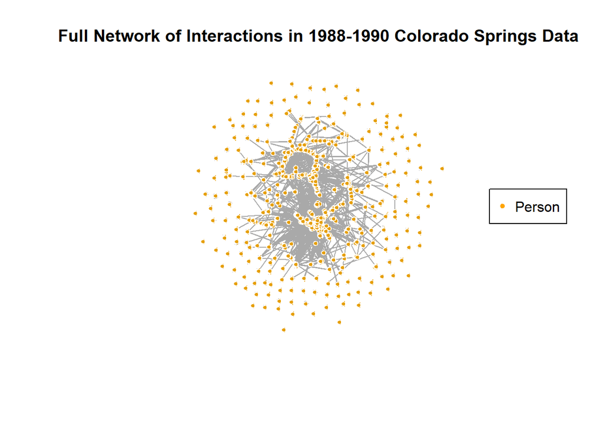

```r
V(g1)$size <- 4
V(g1)$frame.color <- "white"
plot(g1,vertex.label=NA,main="Full Network of Interactions in 1988-1990 Colorado Springs Data")
legend("right",legend="Person",col="orange",pch=20)
```

This obviously does not look very pretty as there are over 5000 nodes and over 20000 edges. Right now, let us partition it such that we keep only the sex workers and the sex worker clients.

```r
#graph_sex<-subgraph.edges(graph=g1,eids=which(V(g1)$sex.worker==1 | which(V(g1)$sex.work.client==1)),delete.vertices = TRUE)
graph_sex<-induced_subgraph(g1,V(g1)$sex.worker==1|V(g1)$sex.work.client!=0)
# graph_sex<-is.na(V(graph_sex)$sex.worker)
# graph_sex<-is.na(V(graph_sex)$sex.work.client)
graph_sex
```

```
## IGRAPH bebbbeb UN-- 755 1903 --
## + attr: name (v/c), race (v/n), gender (v/n), sex.worker (v/n),
## | pimp (v/n), sex.work.client (v/n), drug.dealer (v/n), drug.cook
## | (v/n), thief (v/n), retired (v/n), housewife (v/n), disabled
## | (v/n), unemployed (v/n), homeless (v/n), size (v/n), frame.color
## | (v/c)
## + edges from bebbbeb (vertex names):
##  [1] 1 --10 1 --16 10--16 1 --17 16--21 10--24 1 --25 10--25 16--25 20--25
## [11] 23--25 10--39 16--39 21--39 24--39 25--39 5 --40 10--40 25--40 39--40
## [21] 40--41 24--42 24--44 23--45 24--45 16--47 5 --50 28--50 39--50 40--50
## [31] 35--51 1 --52 16--52 47--52 49--53 40--54 16--55 39--55 5 --57 21--57
## + ... omitted several edges
```

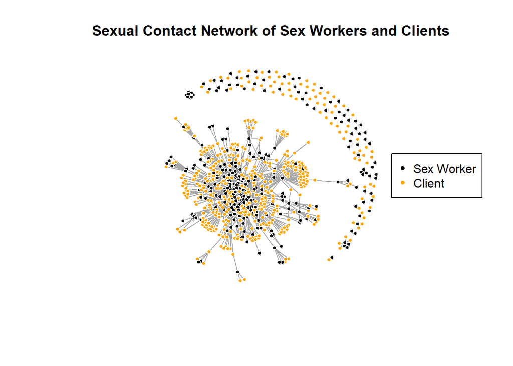

```r
V(graph_sex)$size <- 4
V(graph_sex)$frame.color <- "white"
V(graph_sex)$color <- ifelse(V(graph_sex)$sex.worker == 1, "black", "orange")
plot(graph_sex,vertex.label=NA, main="Sexual Contact Network of Sex Workers and Clients")
legend("right",legend=c("Sex Worker","Client"),col=c("black","orange"),pch=c(20,20))
```

From above, we can see that the sex worker, sex client network is much smaller than the rest of the network and this can help in analysis. Lets find out how many clients we have engaging in sexual services. Also, let’s find out how many sex workers there are.

```r
#V(graph_sex)$sex.worker == 1
num_prostitutes<-sum(as.numeric(V(graph_sex)$sex.worker == 1))
num_prostitutes
```

```
## [1] 288
```

```r
num_clients<-sum(as.numeric(V(graph_sex)$sex.work.client ==1))
num_clients
```

```
## [1] 493
```

```r
summary(graph_sex)
```

```
## IGRAPH 61ad484 UN-- 755 1903 --
## + attr: name (v/c), race (v/n), gender (v/n), sex.worker (v/n),
## | pimp (v/n), sex.work.client (v/n), drug.dealer (v/n), drug.cook
## | (v/n), thief (v/n), retired (v/n), housewife (v/n), disabled
## | (v/n), unemployed (v/n), homeless (v/n), size (v/n), frame.color
## | (v/c), color (v/c)
```

```r
#V(graph_sex)$sex.work.client
#V(graph_sex)$sex.worker
```

Now that we have that information out of the way, let us plot the degree distribution of this sub-network and the degree distribution of the prostitutes and clients separately. We will also plot the log degree-distribution of the networks and the sub-networks.

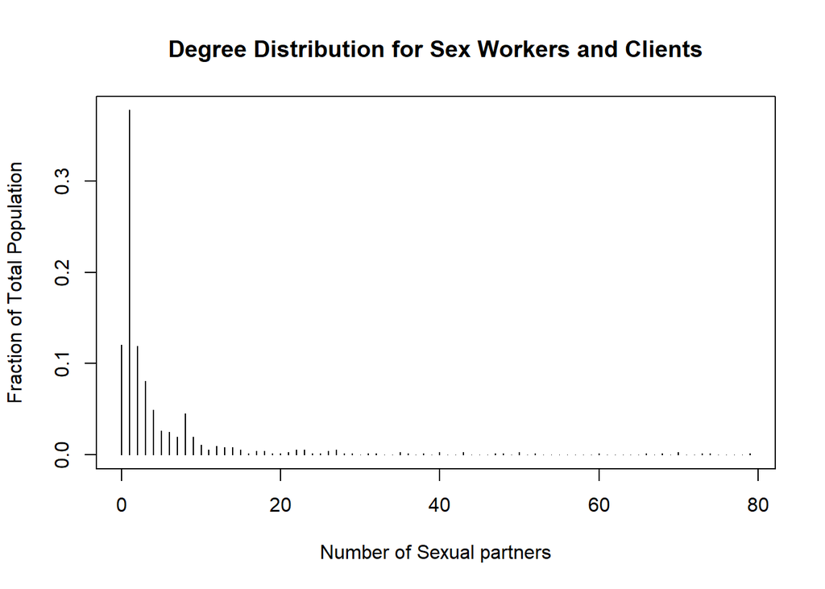

```r
sex_graph_degrees<-degree_distribution(graph_sex)
#sex_graph_degrees
plot(1:length(sex_graph_degrees)-1,sex_graph_degrees,main="Degree Distribution for Sex Workers and Clients",xlab="Number of Sexual partners",ylab="Fraction of Total Population","h")
```

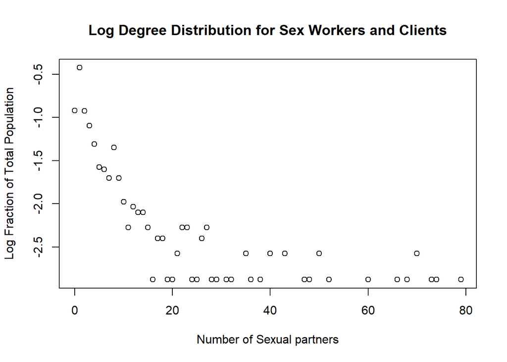

```r
###### log fraction vs log degree
plot(1:length(sex_graph_degrees)-1,log10(sex_graph_degrees),main="Log Degree Distribution for Sex Workers and Clients",xlab="Number of Sexual partners",ylab="Log Fraction of Total Population")
```

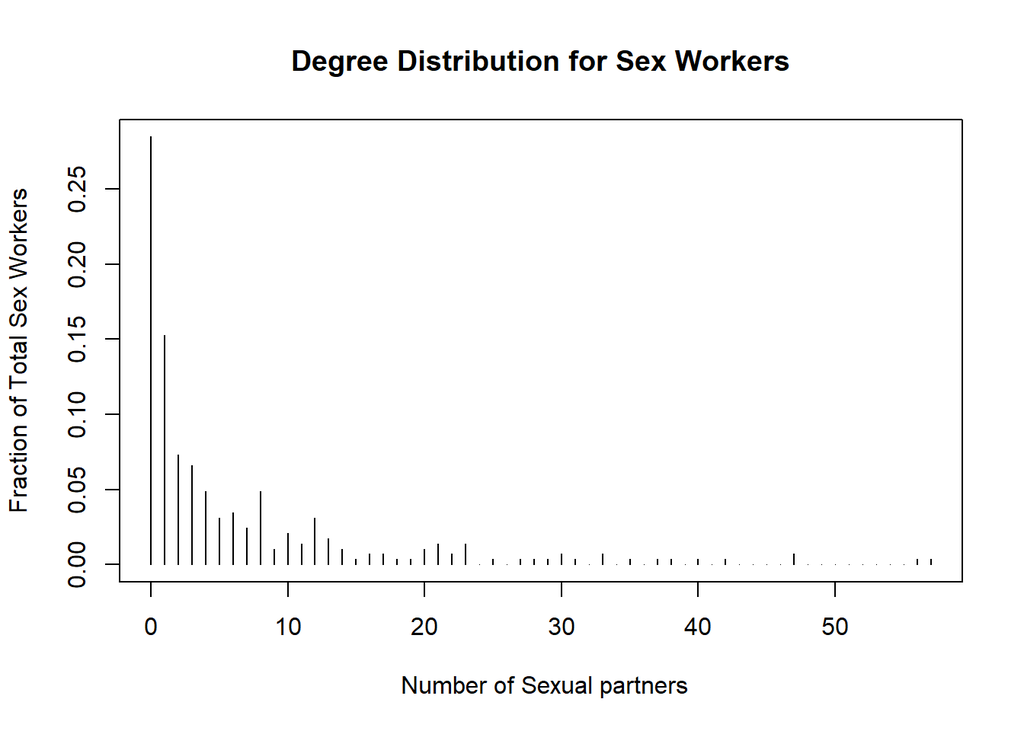

```r
graph_workers<-induced_subgraph(graph_sex,V(graph_sex)$sex.worker==1)
workers_graph_degrees<-degree_distribution(graph_workers)
plot(1:length(workers_graph_degrees)-1,workers_graph_degrees,main="Degree Distribution for Sex Workers",xlab=" Number of Sexual partners",ylab="Fraction of Total Sex Workers","h")
```

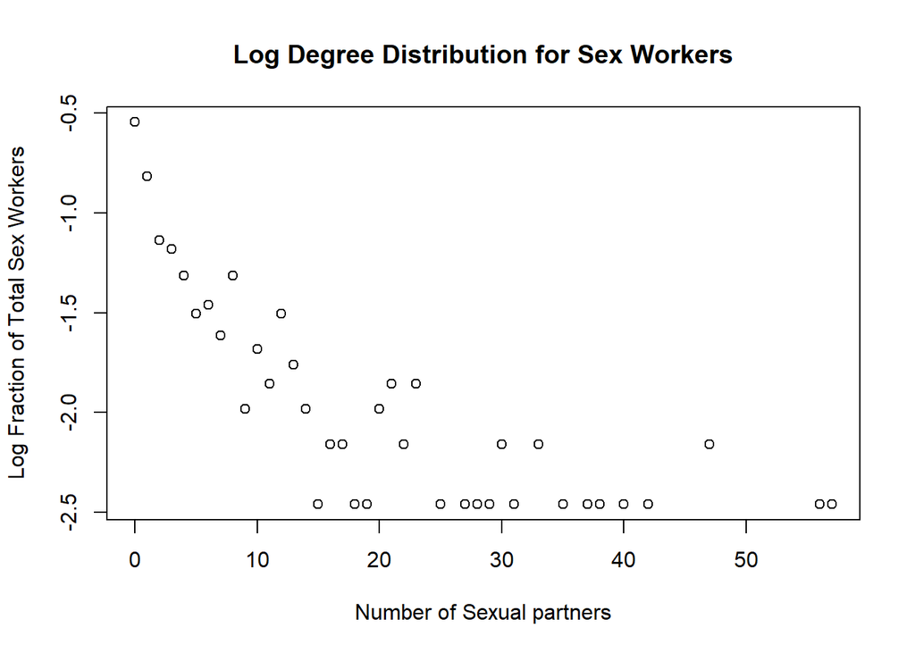

```r
plot(1:length(workers_graph_degrees)-1,log10(workers_graph_degrees),main="Log Degree Distribution for Sex Workers",xlab="Number of Sexual partners",ylab="Log Fraction of Total Sex Workers")
```

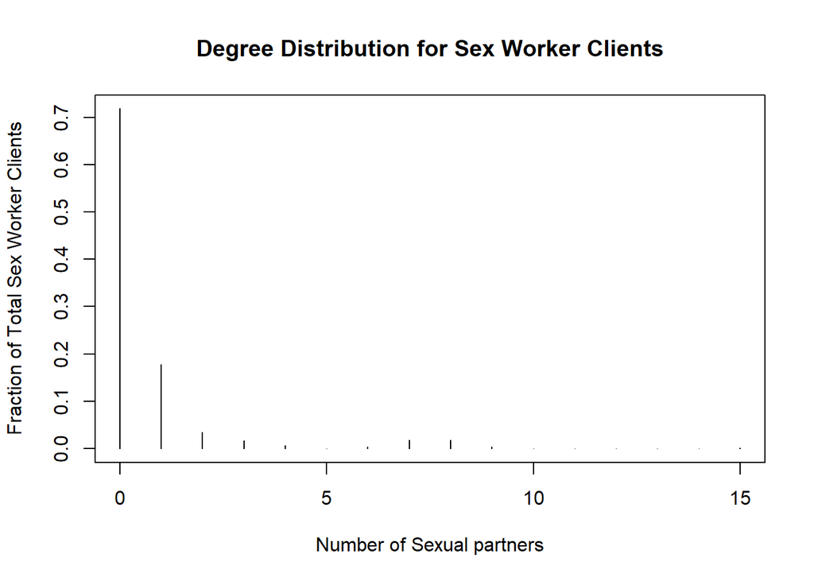

```r
graph_clients<-induced_subgraph(graph_sex,V(graph_sex)$sex.work.client==1)
clients_graph_degrees<-degree_distribution(graph_clients)
plot(1:length(clients_graph_degrees)-1,clients_graph_degrees,main="Degree Distribution for Sex Worker Clients",xlab="Number of Sexual partners",ylab="Fraction of Total Sex Worker Clients","h")
```

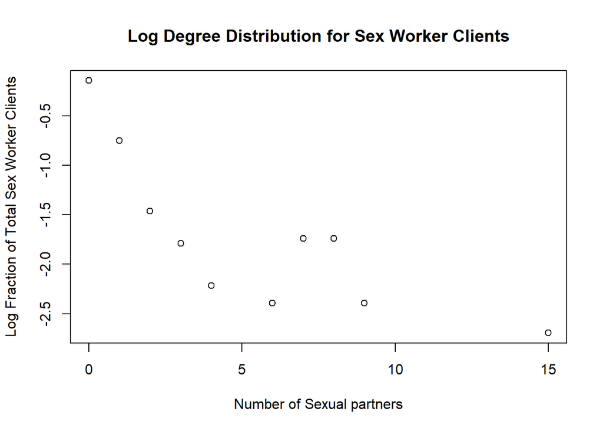

```r
plot(1:length(clients_graph_degrees)-1,log10(clients_graph_degrees),main="Log Degree Distribution for Sex Worker Clients",xlab="Number of Sexual partners",ylab="Log Fraction of Total Sex Worker Clients")
```

```r
###new state
### (0-uninfected) (1-infected) (2-recovered)
```

```r
##Initial Parameters
gamma=0.2
tau=0.0067 #0.67%
#Gamma was chosen arbitrarily, Tau is average for vaginal sex alone.


reed_frost<-function(cm, tau, gamma,reps=1000,ticks=500){
  rep=0
  sizes<-numeric(0)
   while (rep<reps){
      Network_size<-dim(cm)[1]

      Infected_matrix<-matrix(rep(0,Network_size),nrow=Network_size,ncol=1)
      Susceptible_matrix<-matrix(rep(1,Network_size),nrow=Network_size,ncol=1)
      Recovered_matrix<-matrix(rep(0,Network_size),nrow=Network_size,ncol=1)

      #Sample randomly to get patient zero
      patient_0<-sample(1:Network_size,1)
      #print(patient_0)
      #Adjust matrix accordingly
      Infected_matrix[patient_0,1]<-1
      Susceptible_matrix[patient_0,1]<-0
      t<-1
      while(t==1 | sum(Infected_matrix[,t-1])>0 & t<=ticks ){
        t<-t+1
        Neighbors<-cm %*% Infected_matrix[,t-1]
        Probs_for_Neighbors<-1-(1-tau)^Neighbors

        #Sample for infecteds
        I_samp<-rbinom(Network_size,Susceptible_matrix[,t-1],Probs_for_Neighbors)
        R_samp<-rbinom(Network_size,Recovered_matrix[,t-1],gamma)

        #Update matrices
        Susceptible_next<-Susceptible_matrix[,t-1] -I_samp
        Infected_next<- Infected_matrix[,t-1] + I_samp - R_samp
        Recovered_next<- Recovered_matrix[,t-1] + R_samp

        Susceptible_matrix<-cbind(Susceptible_matrix,Susceptible_next)
        Infected_matrix<-cbind(Infected_matrix,Infected_next)
        Recovered_matrix<-cbind(Recovered_matrix,Recovered_next)

        #dim(Recovered_matrix)
        #dim(Infected_matrix)
        } #end while 1 iteration
      #print(Recovered_matrix[,-1])
      #print(Infected_matrix[,-1])
      net_epidemic_size<-sum(Recovered_matrix[,dim(Recovered_matrix)[2]])+sum(Infected_matrix[,dim(Infected_matrix)[2]])
    #   print(sum(Recovered_matrix[,-1]))
    #   print(sum(Infected_matrix[,-1]))
    #   #print(net_epidemic_size)
      sizes<-c(sizes,net_epidemic_size)
    #   print(net_epidemic_size)
      rep<-rep+1
   } #End while all iterations
  return(sizes)

}

adjacency<-as_adjacency_matrix(graph_sex,type="both",sparse=FALSE)
```

```r
#head(adjacency)
dim(adjacency)
```

```
## [1] 755 755
```

```r
#adjacency
Final_epidemic_sizes<-reed_frost(adjacency,tau,gamma,reps=1000)
head(Final_epidemic_sizes)
```

```
## [1] 584   4 550 440   1 576
```

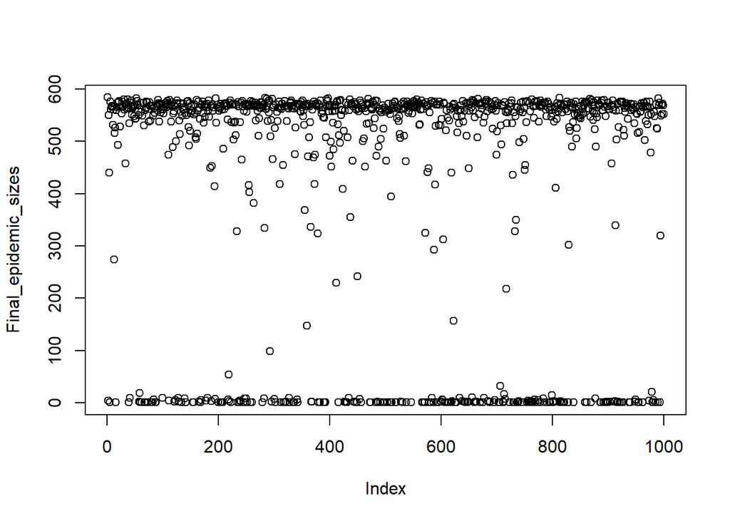

```r
plot(Final_epidemic_sizes)
```

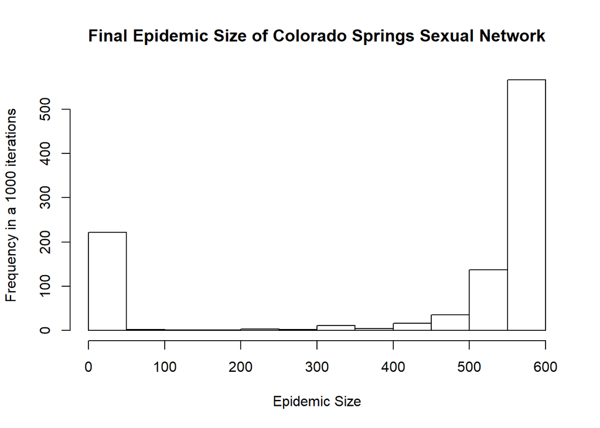

```r
hist(Final_epidemic_sizes,main="Final Epidemic Size of Colorado Springs Sexual Network",xlab="Epidemic Size",ylab="Frequency in a 1000 iterations")
```

```r
##95% CI
quantile(Final_epidemic_sizes,c(0.025,0.975))
```

```
##  2.5% 97.5%
##     1   579
```

```r
#above_500<-Final_epidemic_sizes>500
#sum(above_500)
```

As you can see above the 95% confidence interval for the final epidemic sizes is quite broad because the distribution is almost bivariate.There are a majority of cases which are at 1 or in the high 500s. Therefore, either the epidemic will fail to take off due to self limiting nature, or the epidemic takes off and infects almost everyone.

For this network, disregarding the fact that all interactions happen at the same time can be ok. However, there may be problems when this is scaled.

Now, let us visualize the degree distribution and the log degree distribution of the entire network.

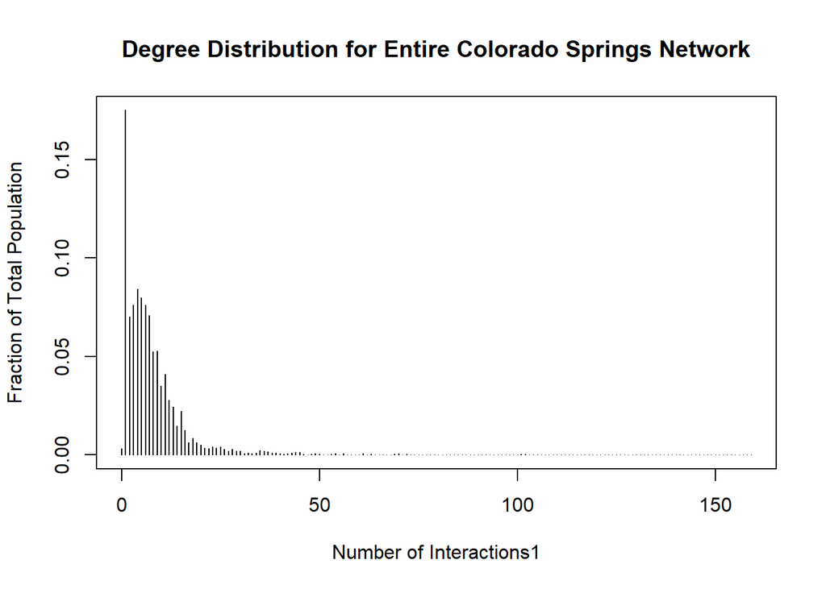

```r
g1_degrees<-degree_distribution(g1)
plot(1:length(g1_degrees)-1,g1_degrees,main="Degree Distribution for Entire Colorado Springs Network",xlab="Number of Interactions1",ylab="Fraction of Total Population","h")
```

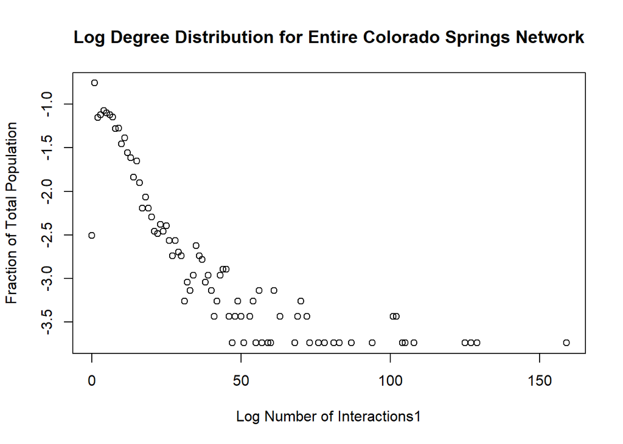

```r
plot(1:length(g1_degrees)-1,log10(g1_degrees),main="Log Degree Distribution for Entire Colorado Springs Network",xlab="Log Number of Interactions1",ylab="Fraction of Total Population")
```

There are intrinsic problems with this simulation because not everyone interacts with everyone at the same time.